# Viridis color palette

Nicholas J. Gotelli

9/6/2018

R has just incorporated the `viridis` palette for heat maps. The advantages are: - a continuous blue to yellow scale that renders detail much more clearly than other palettes - the viridis palette is visible to those with color blindness - the viridis palette translates readily to a well-differentiated grey-scale.

You can read about the details here in this R-bloggers column:

https://www.r-bloggers.com/ggplot2-welcome-viridis/

I will illustrate its power for a heat map applied to a random normal variate. On average, the colors should not change across this heat map, but a good color scale will differentiate fine-scale peaks and valleys in the color landscape.

```r
library(ggplot2)
library(TeachingDemos)
char2seed("Ozark")

# first create the data frame
dFrame <- expand.grid(xVar=1:100,yVar=1:100)
dFrame$z <- rnorm(10000)
```

We start by using the default color palette for visualizing the heat map:

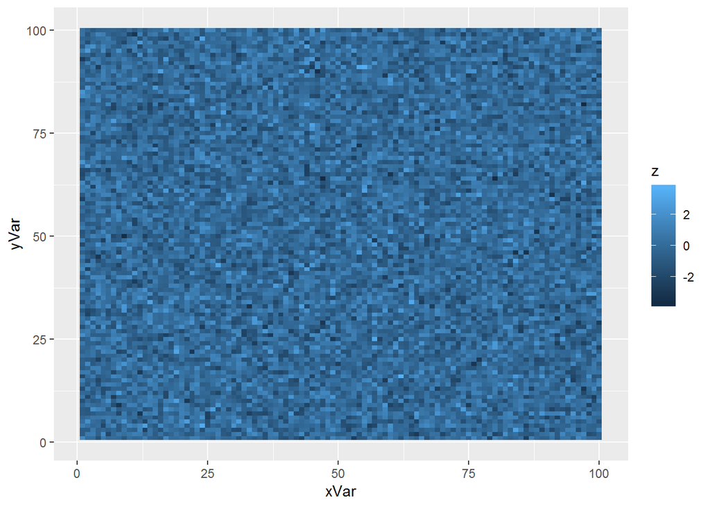

```r
p1 <- ggplot(data=dFrame,aes(x=xVar,y=yVar)) +
      geom_tile(aes(fill=z))
print(p1)
```

Looks OK, but a bit monochrome. Now with the built-in `viridis` color scale:

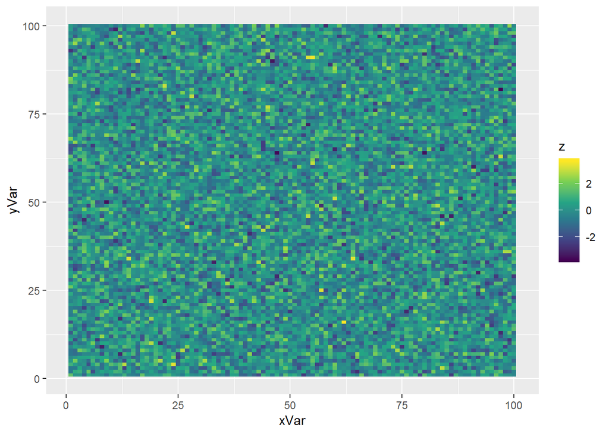

```r
p2 <- ggplot(data=dFrame,aes(x=xVar,y=yVar)) +
      geom_tile(aes(fill=z)) +
scale_fill_viridis_c()
print(p2)
```

This makes it much easier to pinpoint the outliers at both extremes.

Here is some excellent code from Lauren Ash for converting this to a grayscale plot:

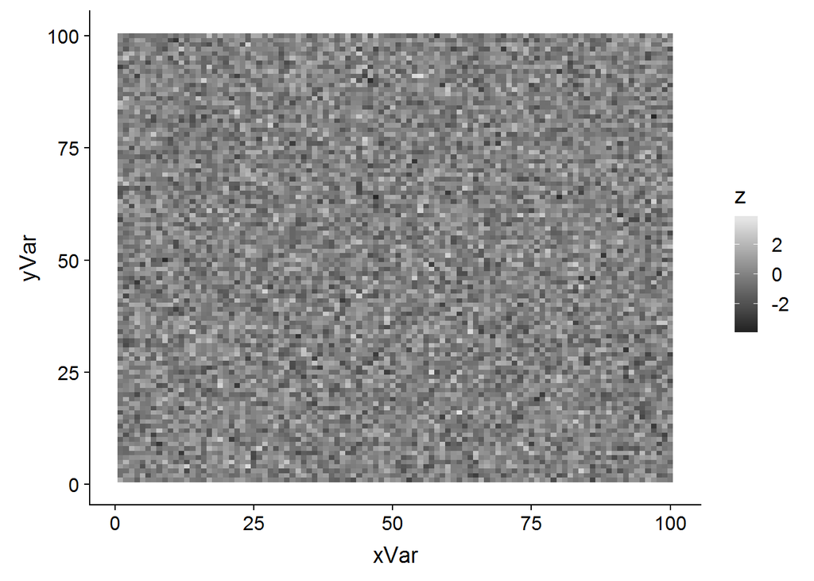

```r
library(colorblindr) # devtools::install_github("clauswilke/colorblindr")
library(colorspace) # install.packages("colorspace", repos = "http://R-Forge.R-project.org") --- colorblindr requires the development version
# this also installs cowplot
library(cowplot)
p3 <- ggplot(data=dFrame,aes(x=xVar,y=yVar)) +
    geom_tile(aes(fill=z)) +
    scale_fill_viridis_c()
p3des<-edit_colors(p3, desaturate)
ggdraw(p3des)
```

Finally, there are some options for other scales that will give a more traditional heat map scale, but with the same features as the viridis scale:

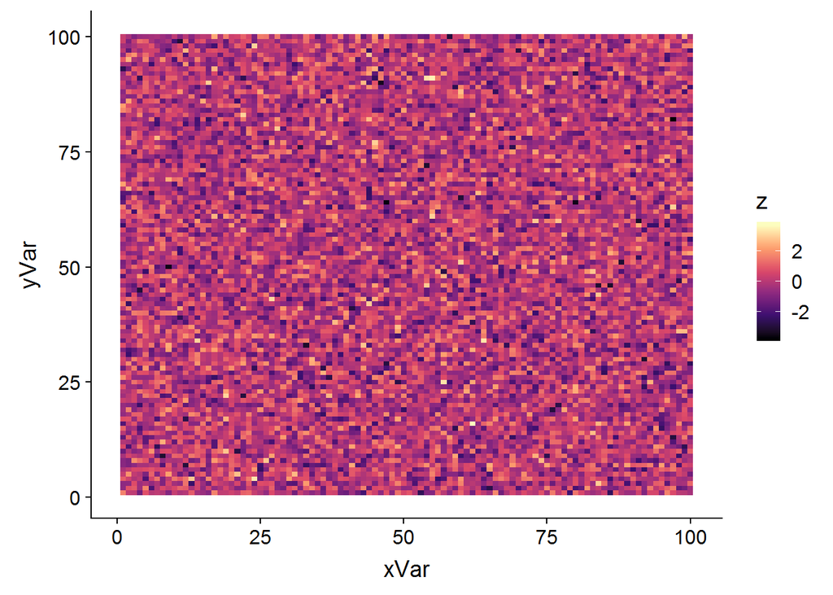

```r
p4 <- ggplot(data=dFrame,aes(x=xVar,y=yVar)) +
      geom_tile(aes(fill=z))
p4 + scale_fill_viridis_c(option="magma") # "A" option
```

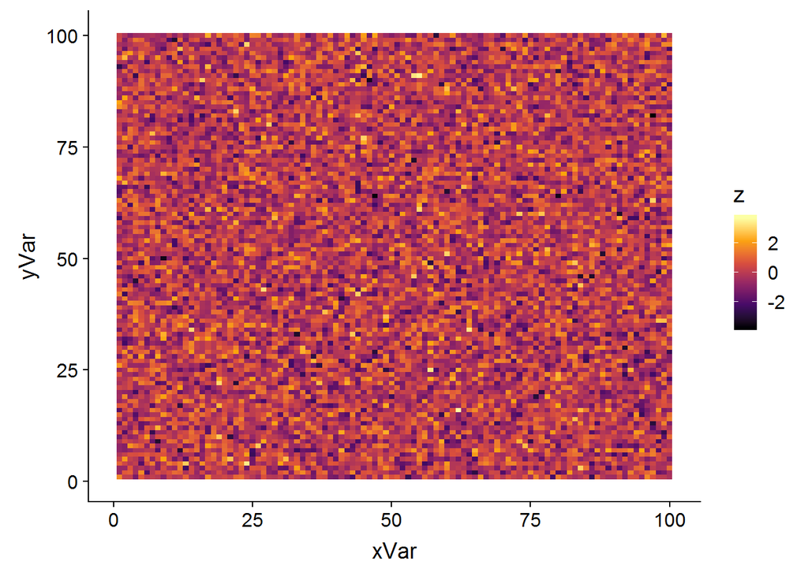

```r
p4 + scale_fill_viridis_c(option="inferno") # "B" option
```

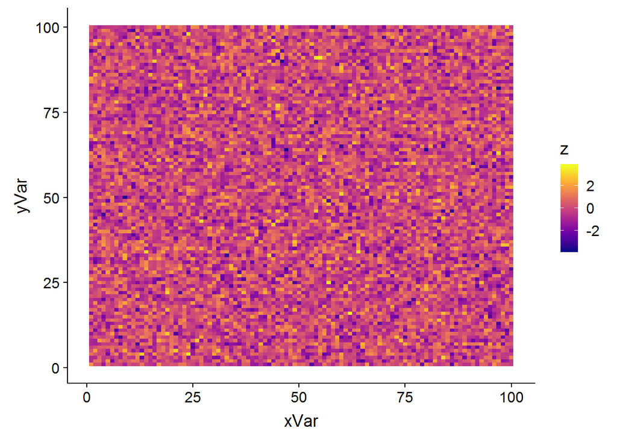

```r
p4 + scale_fill_viridis_c(option="plasma") # "C" option
```

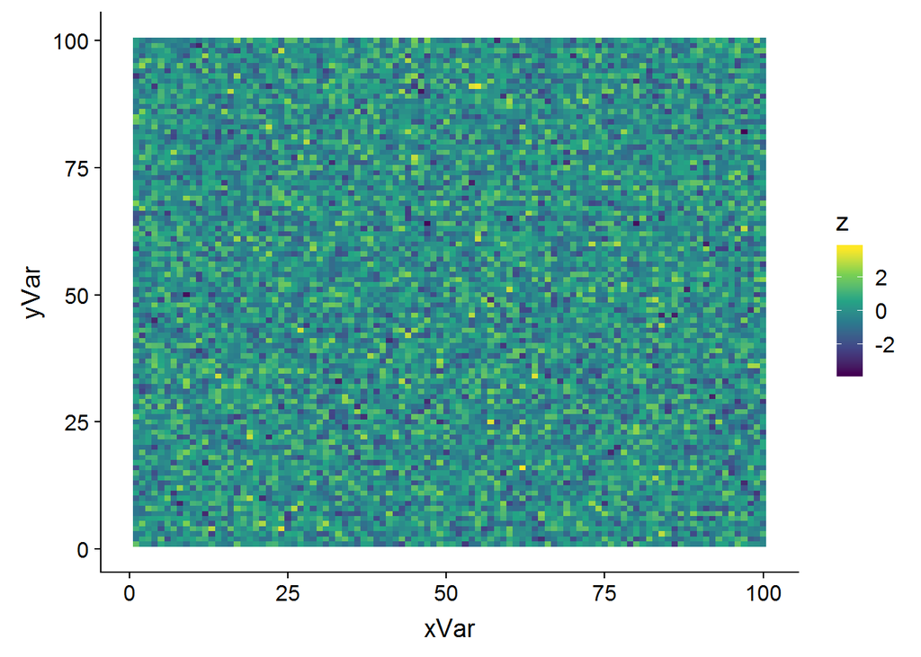

```r
p4 + scale_fill_viridis_c(option="viridis") # "D" (default) option
```

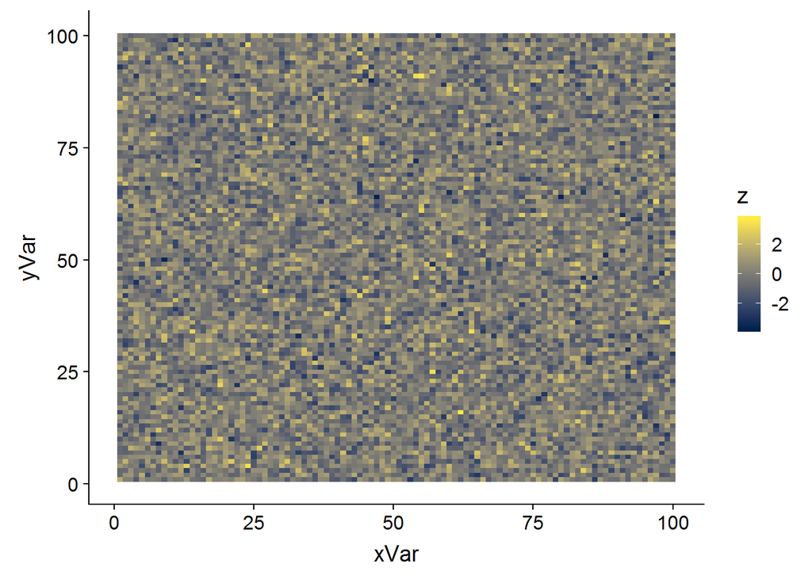

```r
p4 + scale_fill_viridis_c(option="cividis") # "E" option
```

When working with discrete color scales, use the `scale_fill_viridis_d()` function. Like this:

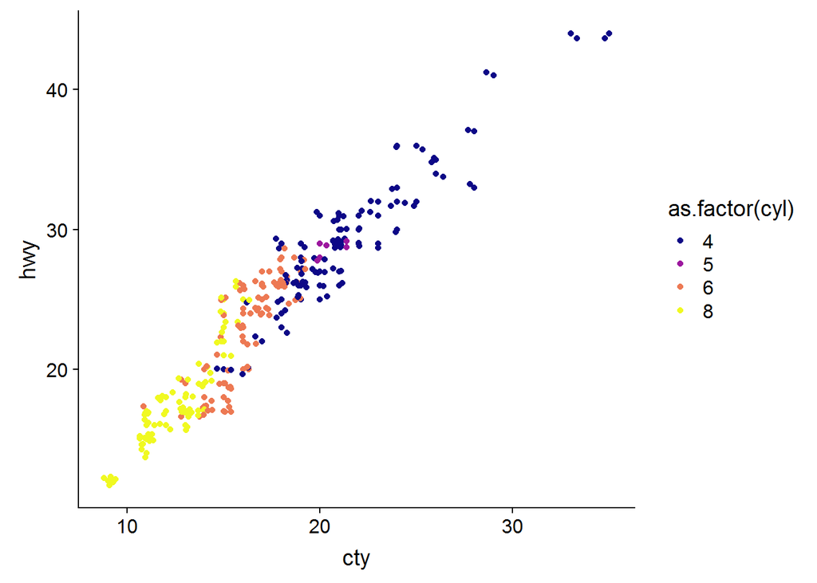

```r
p5 <- ggplot(data=mpg,aes(x=cty,y=hwy,color=as.factor(cyl))) +
geom_point() +
geom_jitter() +
scale_color_viridis_d(option="C")
print(p5)
```